# 19_B_ESmoothing_Model_Selection

# Reading route

The numbered sections follow the slides in the same order, and each slide links to its section here. The notebook adds the R output and the explanations for study after class. One series, Australian holiday trips, runs through all seven.

1. From Holt-Winters to ETS: what Session 18 left us with, and one line of R that fits, chooses and forecasts.
2. The ETS letters: Error, Trend and Season, and the models you have already fitted.
3. From a method to a statistical model: the observation equation, and what additive and multiplicative errors change.
4. Fitting by likelihood: how a prediction’s distribution scores an observation, and the score `ETS()` maximizes.
5. Choosing by AICc: AIC and AICc by hand, and when they can compare models.
6. Check the selected model: the residual checks on the innovation residuals.
7. Forecasting with ETS: forecast distributions, one interval by hand, how intervals grow with the horizon, and the whole route in one table.

The required work is Exercise 1 parts 1, 2 and 5, Exercise 3 parts 1 and 2, and its calculator comparison. Everything else in the exercises, Exercise 2 included, is optional practice. The appendix holds optional supporting material: a short likelihood guide, one update by hand in both error forms, a slice through the likelihood search, the scoreboard of all eligible models and the excluded combinations, BIC, the nested-model argument, comparisons across model families, zeros and transformations, simulated intervals, and where the likelihood score comes from.

# References

1. Hyndman, R.J., & Athanasopoulos, G. (2021). *Forecasting: principles and practice* (3rd ed.), sections 8.4 to 8.7. https://otexts.com/fpp3/
2. Hyndman, R. J., Koehler, A. B., Ord, J. K., & Snyder, R. D. (2008). *Forecasting with exponential smoothing: The state space approach*. Springer-Verlag.
3. Akaike, H. (1974). A new look at the statistical model identification. *IEEE Transactions on Automatic Control*, 19, 716-723.

# Libraries

```r
library(fpp3)
```

# 1. From Holt-Winters to ETS

**Last session.** In Session 18 on Holt-Winters we chose the seasonal form ourselves. The time plot suggested a seasonal effect, we wrote `season("A")` or `season("M")` into `ETS()`, and `ETS()` estimated the weights and initial states of the form we wrote. Held-out quarters then judged the choice.

**Today.** We let `ETS()` choose the form as well. With no letters in the formula, it fits every eligible combination of error, trend and season, ranks them with a score called AICc, and keeps the best. Its forecast comes with a distribution for every future quarter, which gives the intervals. We then check the chosen model and read its forecasts.

|  | Session 18: Holt-Winters | Today: ETS |
| --- | --- | --- |
| The form | we chose it from the time plot and wrote it into `ETS()` | `ETS()` tries every eligible form |
| Fitting | `ETS()` estimated the weights and initial states | the same fitting, now explained: maximum likelihood |
| Choosing | held-out errors on later quarters | AICc on the training data, then residual checks; held-out errors still settle close calls |
| The forecast | a path | a path with a distribution, and so an interval, at every horizon |

Quarterly Australian holiday trips, in millions, as in Session 18. The first model is Session 18’s additive Holt-Winters; the second writes no letters, so `ETS()` chooses:

```r
aus_holidays <- tourism |>
  filter(Purpose == "Holiday") |>
  summarise(Trips = sum(Trips) / 1e3)

fit_open <- aus_holidays |>
  model(
    additive = ETS(Trips ~ error("A") + trend("A") + season("A")),
    auto     = ETS(Trips)
  )

fit_open
```

```
# A mable: 1 x 2
      additive         auto
       <model>      <model>
1 <ETS(A,A,A)> <ETS(M,N,A)>
```

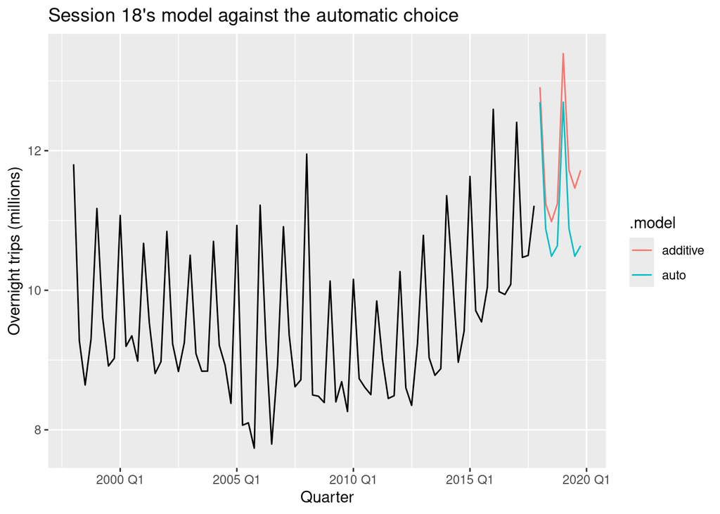

```r
fit_open |>
  forecast(h = 8) |>
  autoplot(aus_holidays, level = NULL) +
  labs(title = "Session 18's model against the automatic choice",
       y = "Overnight trips (millions)")
```

The mable shows the automatic choice, $ETS(M,N,A)$. Its forecasts repeat the seasons on a flat path: 12.7 million trips for 2018 Q1 and again for 2019 Q1, where additive Holt-Winters rises from 12.9 to 13.4 million. In this run `ETS()` chose $ETS(M,N,A)$; a future software version could choose differently, so read the model name in the output. Sections 2 and 3 read its three letters, and section 5 shows why the score preferred a model with no trend.

We keep the automatic model as `fit` for the rest of the notebook:

```r
fit <- fit_open |> select(auto)
```

# 2. The ETS letters

**ETS** stands for **E**rror, **T**rend and **S**eason, the three letters of every model name, in that order:

- **Error:** **A** additive or **M** multiplicative.
- **Trend:** **N** none, **A** additive or **Ad** additive damped. Multiplicative trends are outside this course.
- **Season:** **N** none, **A** additive or **M** multiplicative.

The trend and season letters set the method: the recursions of Sessions 15 to 18. The error letter turns the method into a statistical model, the subject of section 3. You have fitted these models before:

| Model | Method | Where you met it |
| --- | --- | --- |
| $ETS(A,N,N)$ | simple exponential smoothing | Sessions 15 and 16 |
| $ETS(A,A,N)$ | Holt’s linear trend | Session 17 |
| $ETS(A,A,A)$ | additive Holt-Winters | Session 18 |
| $ETS(M,A,M)$ | multiplicative Holt-Winters | Session 18 |

Three of them on the same holiday trips show what the trend and season letters do to a forecast:

```r
fit_letters <- aus_holidays |>
  model(
    `ETS(A,N,N)` = ETS(Trips ~ error("A") + trend("N") + season("N")),
    `ETS(A,A,N)` = ETS(Trips ~ error("A") + trend("A") + season("N")),
    `ETS(A,A,A)` = ETS(Trips ~ error("A") + trend("A") + season("A"))
  )
```

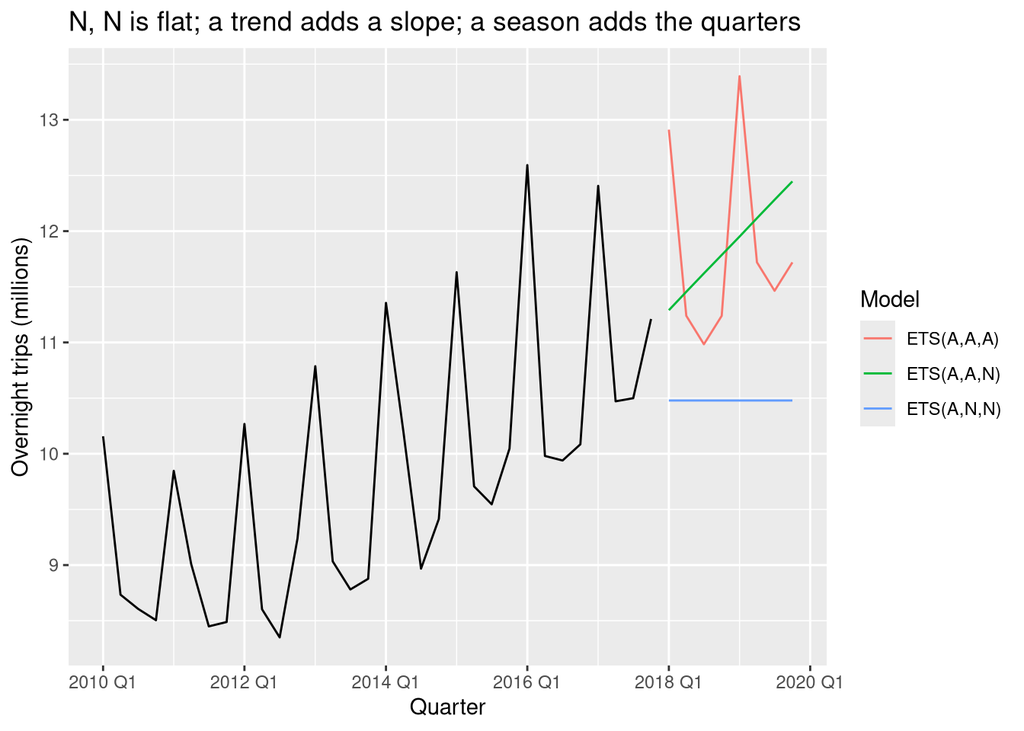

```r
fit_letters |>
  forecast(h = 8) |>
  autoplot(aus_holidays |> filter(year(Quarter) >= 2010), level = NULL) +
  labs(title = "N, N is flat; a trend adds a slope; a season adds the quarters",
       y = "Overnight trips (millions)", colour = "Model")
```

With no trend and no season the forecast is flat at the last level. An additive trend adds a slope. An additive season puts the quarters back. The error letter does not show in these point forecasts; section 3 shows what it changes. Notebook 19_A collects the nine trend and season combinations and the fpp3 table of their recursions, as reference.

**Check: name a model.** You want errors measured in the data’s units, a slope that keeps shrinking the further ahead you forecast, and no seasonal pattern. Which ETS model is it? Then read the automatic choice of section 1, $ETS(M,N,A)$, one letter at a time. Commit before opening.

**TipAnswer: open after naming the model**

- Errors in the data’s units: **A**. A slope that keeps shrinking: **Ad**, the damped trend. No seasonal pattern: **N**. The model is $ETS(A,Ad,N)$, damped Holt from Session 17.
- $ETS(M,N,A)$: **M**, misses are proportions of the prediction, so they grow with the level; **N**, the forecasts carry no slope; **A**, each quarter adds a fixed number of trips to the level. 19_A ends with the same reading as a check.

# 3. From a method to a statistical model

Start with simple exponential smoothing (SES). We predict $y_t$ from the previous level $\ell_{t-1}$ and then update the level by $\alpha$ times the observed miss $e_t=y_t-\hat y_{t|t-1}$. This is the **error-correction form** from Session 15 on SES equations. The value $\hat y_{t|t-1}$ is the **prior prediction** because we make it before observing $y_t$.

The additive-error model, $ETS(A,N,N)$, adds an observation equation. It describes the observation as the prior prediction plus a random surprise $\varepsilon_t$, the **innovation**. In this model, $\varepsilon_t=y_t-\hat y_{t|t-1}$, so the miss $e_t$ in the SES update is the same innovation:

$$\begin{align*}
&\text{Predict } y_t && \hat y_{t|t-1}=\ell_{t-1}\\
&\text{Update the level} && \ell_t=\ell_{t-1}+\alpha\textcolor{#B5471E}{\varepsilon_t}\\
&\textcolor{#B5471E}{\text{Observation}} && \textcolor{#B5471E}{y_t=\ell_{t-1}+\varepsilon_t,\qquad \varepsilon_t\sim N(0,\sigma^2)\text{, independent over time}}
\end{align*}$$

The normal innovation has three consequences:

- **A prediction is the center of a distribution.** Before $y_t$ arrives, the model says $y_t\sim N(\ell_{t-1},\sigma^2)$. Section 4 scores each observation against that distribution.
- **One surprise moves both.** The same innovation that moves $y_t$ away from its prediction moves the level, by $\alpha$ times its size. This is why fpp3 calls these models *innovations state space models* (fpp3 8.5).
- **Future surprises are unknown.** Each one will move a future level, so the model gives a distribution of possible paths, and with it forecast intervals.

After fitting, the miss $e_t=y_t-\hat y_{t|t-1}$ computed from the fitted model is the **fitted innovation residual**. It estimates the innovation that actually occurred. `fable` calls the prior prediction the fitted value, `.fitted`.

## Multiplicative errors

With multiplicative errors the surprise is a proportion of the prediction. The colored terms change:

$$\begin{align*}
&\text{Predict } y_t && \hat y_{t|t-1}=\ell_{t-1}\\
&\text{Error} && \textcolor{#B5471E}{\varepsilon_t=\frac{y_t-\hat y_{t|t-1}}{\hat y_{t|t-1}}}\\
&\text{Update the level} && \ell_t=\ell_{t-1}\textcolor{#B5471E}{(1+\alpha\varepsilon_t)}\\
&\text{Observation} && y_t=\ell_{t-1}\textcolor{#B5471E}{(1+\varepsilon_t)},\qquad \varepsilon_t\sim N(0,\sigma^2)
\end{align*}$$

This is $ETS(M,N,N)$. An innovation of $0.05$ means the observation is 5% above its prediction. Multiplying out the level update gives $\ell_{t-1}+\alpha\ell_{t-1}\varepsilon_t=\ell_{t-1}+\alpha(y_t-\hat y_{t|t-1})$. The SES rule from Session 15 adds $\alpha$ times the miss in the data’s units to the old level. Start with the same level and the same $\alpha$, and both versions give the same updated levels and point forecasts. A hand calculation in the appendix checks this with numbers.

But when `ETS()` fits the two versions separately, it scores their errors differently and can pick different weights and starting levels. That can change their point forecasts. Their prediction intervals can differ even when the point forecasts agree. With multiplicative errors, a surprise of a given percentage means more trips when the forecast is high.

Multiplicative errors need **strictly positive** data. `ETS()` does not consider them for a series with zeros or negative values; the appendix explains why a transformation does not simply fix that.

## What the error letter changes in R

To compare how uncertain the two models are, measure the widths of their 95% prediction intervals in millions of trips. Both models forecast in those units, even though the multiplicative model measures its surprises as proportions. As in Session 12 on prediction intervals, `hilo(level = 95)` creates a 95% interval from each forecast distribution, and `unpack_hilo()` puts its lower and upper bounds in separate columns. Subtract the lower bound from the upper bound to get the width.

Fit the automatic choice and its additive-error twin, then compare those widths quarter by quarter:

```r
fit_errors <- aus_holidays |>
  model(
    additive       = ETS(Trips ~ error("A") + trend("N") + season("A")),
    multiplicative = ETS(Trips ~ error("M") + trend("N") + season("A"))
  )

widths <- fit_errors |>
  forecast(h = 8) |>
  hilo(level = 95) |>
  unpack_hilo(`95%`) |>
  mutate(width = `95%_upper` - `95%_lower`)

widths |>
  as_tibble() |>
  select(.model, Quarter, .mean, width)
```

```
# A tibble: 16 × 4
   .model         Quarter .mean width
   <chr>            <qtr> <dbl> <dbl>
 1 additive       2018 Q1  12.7  1.74
 2 additive       2018 Q2  10.9  1.85
 3 additive       2018 Q3  10.5  1.96
 4 additive       2018 Q4  10.7  2.06
 5 additive       2019 Q1  12.7  2.15
 6 additive       2019 Q2  10.9  2.25
 7 additive       2019 Q3  10.5  2.33
 8 additive       2019 Q4  10.7  2.42
 9 multiplicative 2018 Q1  12.7  2.31
10 multiplicative 2018 Q2  10.9  2.14
11 multiplicative 2018 Q3  10.5  2.18
12 multiplicative 2018 Q4  10.6  2.31
13 multiplicative 2019 Q1  12.7  2.71
14 multiplicative 2019 Q2  10.9  2.57
15 multiplicative 2019 Q3  10.5  2.61
16 multiplicative 2019 Q4  10.6  2.71
```

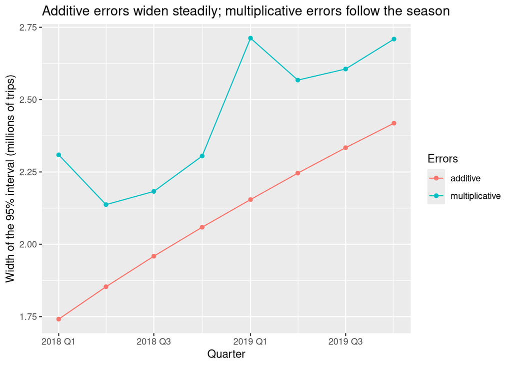

```r
widths |>
  ggplot(aes(x = Quarter, y = width, colour = .model)) +
  geom_line() +
  geom_point() +
  labs(title = "Additive errors widen steadily; multiplicative errors follow the season",
       y = "Width of the 95% interval (millions of trips)", colour = "Errors")
```

The point forecasts of the two models agree to within 0.1 million trips. The intervals do not:

- **Additive errors:** the width grows steadily with the horizon, from 1.74 million trips in 2018 Q1 to 2.42 in 2019 Q4. A surprise has the same spread in trips whatever the quarter.
- **Multiplicative errors:** the width follows the season. It is largest in Q1, the peak, and *falls* from 2018 Q1 to 2018 Q2 although the horizon grows, because Q2 forecasts fewer trips and a proportional surprise is then smaller in trips. Compare the same quarter a year later and it grows: 2.31 in 2018 Q1, 2.71 in 2019 Q1.

## Response and innovation residuals

The random innovation belongs to the model; an innovation residual is reconstructed after fitting. With multiplicative errors, response and innovation residuals differ. `augment()` returns both:

- **Response residuals** (`.resid`): $y_t - \hat{y}_{t|t-1}$, in the data’s units.
- **Innovation residuals** (`.innov`):
  - additive error model: $\hat{\varepsilon}_t = y_t - \hat{y}_{t|t-1}$;
  - multiplicative error model: $\hat{\varepsilon}_t = \dfrac{y_t - \hat{y}_{t|t-1}}{\hat{y}_{t|t-1}}$, a relative error.

For multiplicative errors, apply the checks from Session 9 on residual diagnostics to `.innov`, because this is the relative error the model assumes. The holiday-trips model has multiplicative errors, so its diagnostics use `.innov`.

# 4. Fitting by likelihood

## Score each prediction’s distribution at its observation

SES gives us the rule for updating the level and making the next forecast. In Session 16 we chose its weight $\alpha$ and initial level $\ell_0$ by minimizing the sum of squared errors (SSE). In Sessions 17 and 18 we specified Holt and Holt-Winters and let `ETS()` choose their weights and starting values. By default it maximizes the log-likelihood. For the additive-error examples, the Gaussian log-likelihood and SSE favor the same settings. Today we explain that connection and see how likelihood handles multiplicative errors, where the expected spread in trips grows with the prediction.

Here is how the **likelihood** scores a candidate:

1. For each training quarter, take the distribution of the prior prediction, from section 3.
2. Read the **height** of its density curve at the observed $y_t$.
3. Multiply the heights over all training quarters to get the likelihood, or add their logarithms to get the **log-likelihood**.

A higher likelihood means the observations are more plausible under that candidate’s predictions. For continuous data, a density height is not the probability of one exact value, and it can be larger than one. The short likelihood guide in the appendix explains the distinction.

The chart shows steps 1 and 2 for 2017 Q1. The normal curve is centered on the prior prediction, with a standard deviation of the prediction times $\sigma$, because the errors are relative. Its height at the observed value is **one factor** in the likelihood.

`glance()` gives one row of fit statistics per fitted model, including the estimated innovation variance (`sigma2`), log-likelihood (`log_lik`), and AICc. Here we take the square root of `sigma2` to get $\sigma$, the standard deviation of the relative innovations.

```r
sigma2 <- glance(fit)$sigma2

quarter_scores <- augment(fit) |>
  mutate(sd = .fitted * sqrt(sigma2),
         height = dnorm(Trips, mean = .fitted, sd = sd))

three_quarters <- quarter_scores |>
  filter(between(Quarter, yearquarter("2017 Q1"), yearquarter("2017 Q3")))

one_quarter <- three_quarters |> filter(Quarter == yearquarter("2017 Q1"))
```

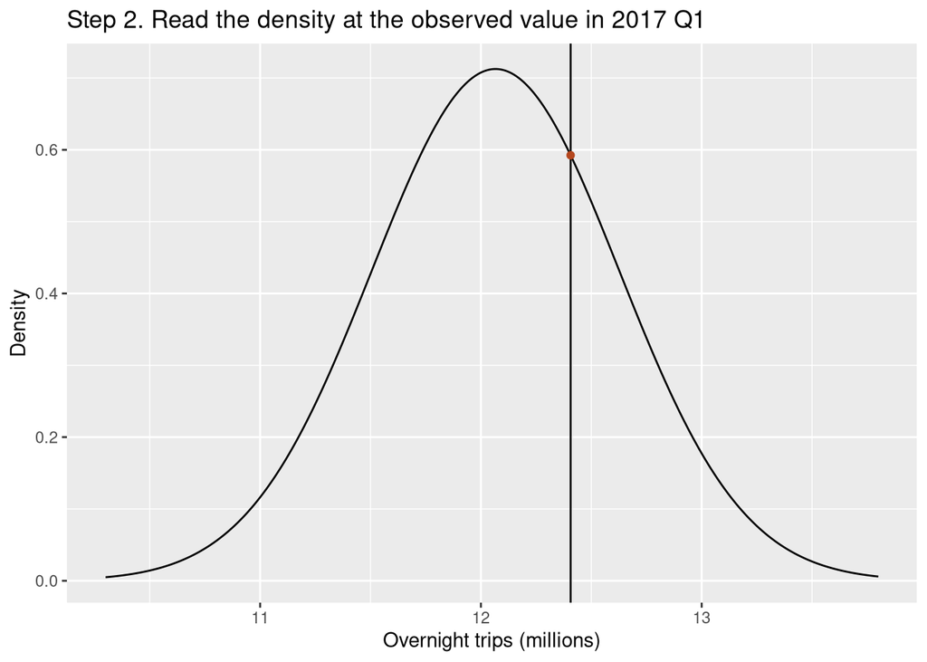

```r
tibble(y = seq(10.3, 13.8, by = 0.01)) |>
  mutate(density = dnorm(y, one_quarter$.fitted, one_quarter$sd)) |>
  ggplot(aes(x = y, y = density)) +
  geom_line() +
  geom_vline(xintercept = one_quarter$Trips) +
  annotate("point", x = one_quarter$Trips, y = one_quarter$height, colour = "#B5471E") +
  labs(title = "Step 2. Read the density at the observed value in 2017 Q1",
       x = "Overnight trips (millions)", y = "Density")
```

**Step 3. Combine the quarters.** Repeat the same calculation with each quarter’s prediction and observed value. The table shows three of the 80 factors.

```r
three_quarters |>
  as_tibble() |>
  select(Quarter, `Prediction (millions)` = .fitted, `Observed (millions)` = Trips,
         `Density height` = height) |>
  knitr::kable(digits = 3)
```

| Quarter | Prediction (millions) | Observed (millions) | Density height |
| --- | --- | --- | --- |
| 2017 Q1 | 12.066 | 12.406 | 0.592 |
| 2017 Q2 | 10.372 | 10.471 | 0.811 |
| 2017 Q3 | 10.011 | 10.499 | 0.495 |

The three heights multiply to about 0.238. Using the same rule for all 80 quarters and the reported variance gives a likelihood of 4.88e-20 and a log-likelihood of -44.47. Adding logs gives the same comparison as multiplying heights, even when the product is very small.

For the fitting comparison below, use `fable`’s reported score. It uses the variance that maximizes likelihood and drops a constant common to candidates on these data. The appendix shows how it gets that score.

## From the SSE search to the likelihood search

Changing $\alpha$ changes how far the level moves after each observation. That changes later predictions and the density heights at the observed values. Keep $\gamma$ and the starting values fixed and try two values of $\alpha$. On `fable`’s log-likelihood scale, the scores across all 80 quarters are $-121.95$ at $\alpha=0.10$ and $-106.11$ at the fitted $\alpha\approx0.35$. The fitted value has the higher score, so it fits better. The appendix reproduces the comparison in R.

`ETS()` runs the same kind of search as Session 16. For $ETS(M,N,A)$ it tries six values together, $\alpha$, $\gamma$, the initial level and the three free initial seasonal states. For each set of values, it runs the predict-observe-update loop through the training quarters. It keeps the settings with the highest total log-likelihood. The best innovation variance $\sigma^2$ for each candidate follows from its errors. AIC counts it as the seventh estimated value in section 5.

- **Additive errors.** For a given model on the same data, with the same parameter bounds, maximizing the Gaussian likelihood and minimizing SSE favor the same weights and starting values.
- **Multiplicative errors.** The two scores differ: the likelihood scores relative errors, with a term that converts them back to trips (appendix). `ETS()` maximizes the likelihood in both cases.

# 5. Choosing by AICc

## AIC: fit plus a charge for every estimated value

The likelihood chooses values *within* a form. To compare *different* forms, we need a score that also charges for flexibility, because a form with more parameters can usually fit the training data a little better. Akaike’s Information Criterion adds that charge, in color:

$$\text{AIC} = -2\log(L)\textcolor{#B5471E}{{}+2k}$$

- $L$ is the maximized likelihood of the model.
- $k$ is the number of values that have been estimated: parameters and free initial states, **including the residual variance**. It measures the complexity of the model.

Among comparable candidates, prefer the smaller AIC. Improving fit lowers the first term, while every extra estimated value adds 2. Here $k$ includes the variance, unlike the $K$ in the residual-scale correction of Session 16 on fitting SES.

## AICc: the bias-corrected AIC

For small samples (small $T$, the length of the series), the AIC tends to choose models with too many parameters. The corrected version charges more:

$$\text{AIC}_{\text{c}} = \text{AIC}\textcolor{#B5471E}{{}+\frac{2k(k+1)}{T-k-1}}$$

As with the AIC, lower is better. `ETS()` uses the $AIC_c$ by default when it chooses a model. The correction matters most when $T$ is small relative to $k$; for the holiday-trips model below, with $T=80$ quarters and $k=7$, it adds about 1.6.

## Reading the selected model

The continuing example is `aus_holidays`, built in section 1: holiday trips summed over regions and converted from thousands to millions. `fit` is its automatic model.

Four functions read a fitted model. `report()` shows which form was chosen, together with its estimates and criteria. `tidy()` returns the estimates as a table, one estimate per row. `glance()` returns a single summary row for each model, with `log_lik`, AIC, AICc and BIC among its columns. `components()` returns the paths of the level and the seasonal states, which `autoplot()` draws.

```r
report(fit)
```

```
Series: Trips
Model: ETS(M,N,A)
  Smoothing parameters:
    alpha = 0.3484054
    gamma = 0.0001000018

  Initial states:
     l[0]       s[0]      s[-1]      s[-2]    s[-3]
 9.727072 -0.5376106 -0.6884343 -0.2933663 1.519411

  sigma^2:  0.0022

     AIC     AICc      BIC
226.2289 227.7845 242.9031
```

```r
fit |> tidy()
```

```
# A tibble: 7 × 3
  .model term   estimate
  <chr>  <chr>     <dbl>
1 auto   alpha  0.348
2 auto   gamma  0.000100
3 auto   l[0]   9.73
4 auto   s[0]  -0.538
5 auto   s[-1] -0.688
6 auto   s[-2] -0.293
7 auto   s[-3]  1.52
```

```r
fit |> glance() |> select(.model, log_lik, AIC, AICc, BIC)
```

```
# A tibble: 1 × 5
  .model log_lik   AIC  AICc   BIC
  <chr>    <dbl> <dbl> <dbl> <dbl>
1 auto     -106.  226.  228.  243.
```

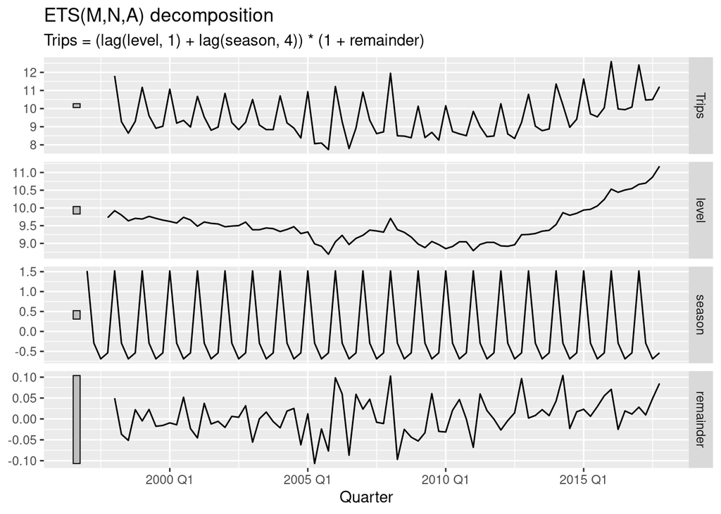

```r
fit |> components() |> autoplot()
```

Read the three letters before interpreting the parameters:

- **M, multiplicative errors.** Misses scale with the level. `report()` rounds $\sigma^2$ to 0.0022 (0.00215 before rounding), so a one-step relative miss has a standard deviation of about $\sqrt{0.00215}\approx0.046$, or 4.6% of the prediction.
- **N, no trend.** The forecasts carry no slope.
- **A, additive seasonality.** Each quarter’s effect is a fixed number of trips. The initial seasonal states put Q1 about 1.52 million trips above the level and Q3 about 0.69 million below it. As in Session 18 on Holt-Winters, `tidy()` lists them backward in time: `s[-3]` is Q1 and `s[0]` is Q4.
- **The weights.** $\alpha\approx0.35$ lets the level adapt, while $\gamma\approx0.0001$ means that the seasonal pattern barely changes over the twenty years.

**Counting $k$.** `glance()` computes the AIC with $k=7$ for this model: $\alpha$, $\gamma$, the initial level $\ell_0$, three free initial seasonal states and the innovation variance $\sigma^2$. Then AIC $=-2(-106.114)+2\times7=226.23$, as `glance()` reports. The calculator comparison supplies $k$ for its models.

**NoteWhy three seasonal states, not four**

`tidy()` lists four initial seasonal states, but they are constrained to sum to zero ($1.519-0.293-0.688-0.538\approx0$), so the fourth follows from the other three and is not a separate estimate. With monthly data, eleven of the twelve are free.

**Check: does a trend earn its place?** Session 18 on Holt-Winters fitted holiday trips with an additive trend. Adding that trend to the selected model gives $ETS(M,A,A)$, and its log-likelihood rises from $-106.114$ to $-104.265$. The trend costs two more estimates, the slope weight $\beta$ and the initial slope $b_0$, so $k=9$. Compute both AIC values: which model does the referee keep? Commit before opening.

**TipAnswer: open after choosing a model**

$ETS(M,N,A)$: $212.23+14=226.23$. $ETS(M,A,A)$: $208.53+18=226.53$. The trend raises the log-likelihood by 1.85, so the fit term falls by 3.70, but the penalty rises by 4. The AIC therefore keeps the model without a trend, narrowly. With 80 quarters, the AICc charges more for each extra parameter and widens the gap, 227.78 against 229.10:

```r
fit_trend <- aus_holidays |>
  model(
    MNA = ETS(Trips ~ error("M") + trend("N") + season("A")),
    MAA = ETS(Trips ~ error("M") + trend("A") + season("A"))
  )

fit_trend |>
  glance() |>
  select(.model, log_lik, AIC, AICc) |>
  knitr::kable(digits = 2)
```

| .model | log_lik | AIC | AICc |
| --- | --- | --- | --- |
| MNA | -106.11 | 226.23 | 227.78 |
| MAA | -104.26 | 226.53 | 229.10 |

`knitr::kable(digits = 2)` prints the table with two decimals, whereas a tibble would print these values as whole numbers, such as `226.`. The referee keeps $ETS(M,N,A)$, the model the automatic search chose.

## Automatic ETS model selection

### How to ask `ETS()` to choose

When the formula does not fix a component, `ETS()` tries every allowed option for it and keeps the model with the lowest $AIC_c$. With no specials, `ETS(y)` searches applicable combinations. Frequency, positivity, data length and fitting restrictions can reduce the candidates; annual nonseasonal data do not get seasonal models.

For holiday trips, 15 combinations are eligible; three others are left out because they can be numerically unstable (appendix). Every seasonal model beats every nonseasonal one by more than 130, so seasonality is not in doubt. At the top the race is close: $ETS(M,N,M)$ is 0.56 behind $ETS(M,N,A)$ and $ETS(M,A,A)$ 1.32 behind. The appendix fits all 15 and charts the gaps.

## When AICc can compare models

Use AICc between models fitted to the **same observations on the same response scale**, as all 15 holiday-trip models are. The A-error and M-error models can be compared because both likelihoods are densities of the same $y$, although their residuals are on different scales. Do not compare the reported AICc of a model for `y` with one for `log(y)`: the likelihoods are of different variables.

When that comparability is in doubt, or when the decision depends on a particular horizon, compare forecasts on held-out data instead, with rolling-origin evaluation from Session 14 on cross-validation. That is also the way to separate close candidates, such as the top three for holiday trips. The appendix gives the general condition.

# 6. Check the selected model

**In-class check.** Work through the four residual checks of Session 9 on residual diagnostics, using the innovation residuals. Where does the selected model still fall short? Discuss before opening the interpretation.

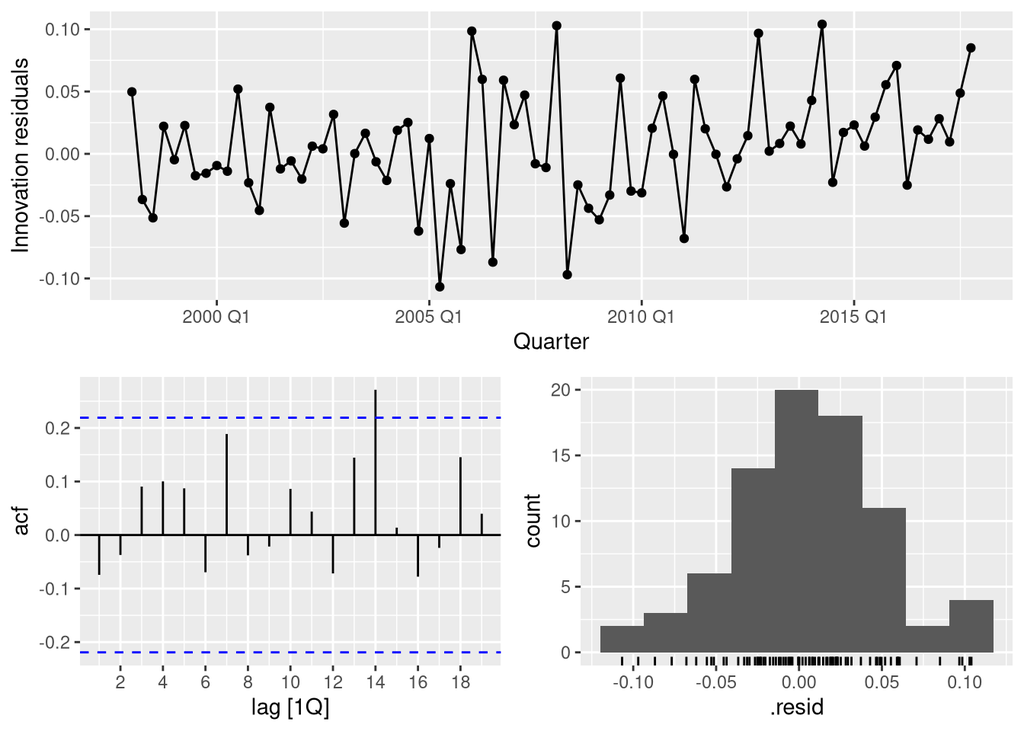

```r
fit |> gg_tsresiduals()
```

```r
augment(fit) |> features(.innov, ljung_box, lag = 8)
```

```
# A tibble: 1 × 3
  .model lb_stat lb_pvalue
  <chr>    <dbl>     <dbl>
1 auto      6.57     0.584
```

All three panels plot the innovation residuals, `.innov`, although the histogram’s axis is labeled `.resid`.

**TipWorked interpretation: open after discussing in class**

- **Mean (time plot).** The innovations average about +0.5%, so on average the prior predictions were slightly too low.
- **Spread (time plot).** From 1998 to 2004 the misses stay within about ±6%; from 2005 on they reach about ±10%. The spread is not constant, which matters for the width of the intervals.
- **Autocorrelation (ACF and Ljung–Box).** Only the bar at lag 14 crosses the band, and the Ljung–Box test with lag 8, twice the quarterly period, gives p = 0.58. There is little evidence of autocorrelation at short lags.
- **Distribution shape (histogram).** Roughly symmetric around zero. As in Session 12 on prediction intervals, normality matters for the intervals, not for the point forecasts.
- **What the model still misses.** 11 of the last 12 innovations are positive. The series rises from 2015, and a model without a trend keeps predicting too little, so its forecasts start from slightly behind.

Inspect innovation residuals for remaining structure. If the chosen model leaves predictable patterns, reconsider the candidates. A low AICc and a nonsignificant test alone do not guarantee suitability for every business horizon.

# 7. Forecasting with ETS

Generate forecasts only after stating the purpose and horizon. Here eight quarters illustrate the possible path and its uncertainty, in the original units (fpp3 8.7). First the point forecasts alone; the intervals follow the check below.

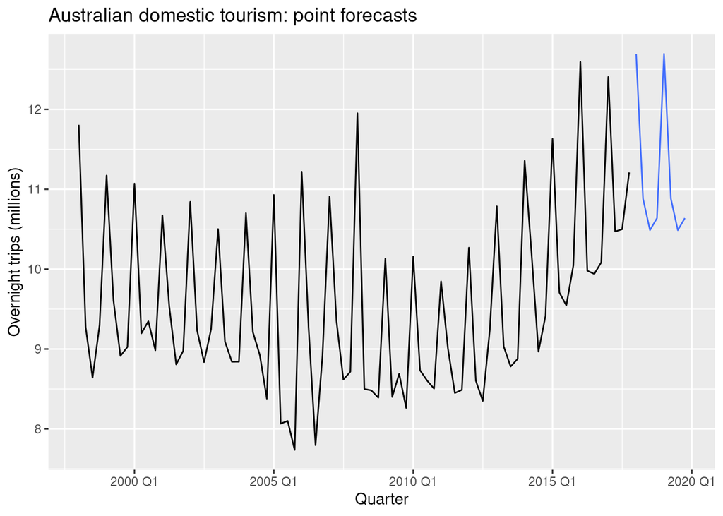

```r
fc <- fit |> forecast(h = 8)

fc |>
  autoplot(aus_holidays, level = NULL) +
  labs(title = "Australian domestic tourism: point forecasts",
       y = "Overnight trips (millions)")
```

For this $ETS(M,N,A)$ model, `forecast()` returns a normal distribution for each quarter, with no simulation. Its mean, in the `.mean` column, is the point forecast, and its 95% interval is the mean plus or minus 1.96 forecast standard deviations. With multiplicative errors, the spread is proportional to the level of the series. Other ETS models may simulate their intervals; the appendix explains how.

## The one-step interval by hand

The first forecast, 2018 Q1, is one step ahead, so its distribution is the one from section 4: normal, centered on the point forecast, with a standard deviation of the point forecast times $\sigma$. Print the mean and standard deviation with four decimals:

```r
fc |>
  as_tibble() |>
  mutate(mean = mean(Trips), sd = sqrt(distributional::variance(Trips))) |>
  select(Quarter, mean, sd) |>
  head(1) |>
  knitr::kable(digits = 4)
```

| Quarter | mean | sd |
| --- | --- | --- |
| 2018 Q1 | 12.6954 | 0.5891 |

With $\sigma=\sqrt{0.002153}=0.0464$, the standard deviation is $12.695\times0.0464=0.589$, and the 95% interval is $12.695\pm1.96\times0.589$, that is $[11.54,\,13.85]$ million trips, as `hilo()` reports below. Rounding the mean to 12.7 before multiplying moves the lower end to 11.55: carry the decimals until the last step.

## Will the interval repeat too?

**Check.** The point forecast for 2019 Q1 equals the one for 2018 Q1, 12.70 million trips, because the model has no trend and its seasonal pattern is fixed. Will the two 95% intervals match as well? Commit before opening.

**TipAnswer: open after predicting**

No. The 2018 Q1 interval is [11.54, 13.85], and the 2019 Q1 interval widens to [11.34, 14.05]. The point forecast repeats, but four more quarters of possible surprises can move the level, so the uncertainty grows with the horizon even when the point forecasts repeat.

```r
fc |>
  hilo(level = 95) |>
  as_tibble() |>
  select(Quarter, .mean, `95%`)
```

```
# A tibble: 8 × 3
  Quarter .mean                   `95%`
    <qtr> <dbl>                  <hilo>
1 2018 Q1  12.7 [11.540826, 13.85002]95
2 2018 Q2  10.9 [ 9.814061, 11.95109]95
3 2018 Q3  10.5 [ 9.396164, 11.57892]95
4 2018 Q4  10.6 [ 9.485864, 11.79090]95
5 2019 Q1  12.7 [11.339233, 14.05161]95
6 2019 Q2  10.9 [ 9.598829, 12.16633]95
7 2019 Q3  10.5 [ 9.184652, 11.79043]95
8 2019 Q4  10.6 [ 9.283806, 11.99295]95
```

The fan chart draws the 80% and 95% intervals for every quarter:

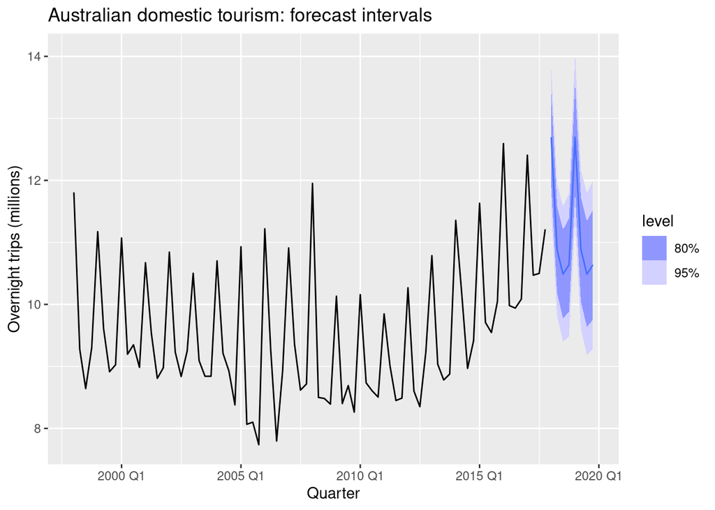

```r
fc |>
  autoplot(aus_holidays) +
  labs(title = "Australian domestic tourism: forecast intervals",
       y = "Overnight trips (millions)")
```

Compare quarters a year apart, not neighbors. As in section 3, a multiplicative-error interval can be narrower in Q2 than in the Q1 before it, because Q2 forecasts fewer trips; the same quarter a year later is always wider.

## The route for holiday trips

| Step | Tool | What it gave for holiday trips |
| --- | --- | --- |
| Choose a form | the three ETS letters | 15 eligible forms; $ETS(M,N,A)$ reads as proportional misses, no slope, fixed seasonal effects in trips |
| Fit | maximum likelihood | $\alpha\approx0.35$, $\gamma\approx0.0001$, the initial level and seasonal states, and $\sigma^2\approx0.0022$ |
| Select | AICc | $ETS(M,N,A)$, with $ETS(M,N,M)$ and $ETS(M,A,A)$ close behind |
| Check | innovation residuals | little autocorrelation, but 11 of the last 12 misses positive since the rise of 2015 |
| Forecast | forecast distributions | flat seasonal path at 12.7 million for each Q1, intervals that widen with the horizon |

Suppose the decision is next summer’s capacity. The AICc barely separates the three leading candidates, and the residuals say the selected model lags a rising series. Held-out evidence settles that kind of close call: compare the candidates’ forecast errors at the horizon of the decision, with rolling-origin evaluation, before committing to one.

# Exercise 1

The `tourism` dataset measures quarterly Australian domestic overnight trips in thousands. Keep the rows with purpose `Holiday`. The result has one series for each combination of `Region` and `State` (check the key of the tsibble).

1. Fit an automatic ETS model to every series, chosen by $AIC_c$.
2. Report the model chosen for the region of Brisbane, and say in one sentence what each of its three letters means for this series.
3. **Optional.** Plot the components of the Brisbane model.
4. **Optional.** Forecast eight quarters for every region, and plot the Brisbane forecasts with the data.
5. Without R, name the ETS model that each description asks for, and say which feature set each letter:
   1. Forecast misses of about the same size in trips at any level of the series, no trend, and a summer quarter about 20 thousand trips above the series level each year, whether the year is busy or quiet.
   2. Forecast misses that stay a roughly constant percentage of the forecast, a slope that the forecasts extend at a constant rate for as far ahead as you look, and no seasonal pattern.
   3. Forecast misses that stay a roughly constant percentage of the forecast, no trend, and seasonal effects that act as percentages of the level, so a busier year has bigger seasonal swings.

# Exercise 2

**Optional practice.**

Sum the trips with purpose `Holiday` over all regions, as in the continuing example (in thousands of trips this time).

1. Fit an automatic ETS model and report it.
2. Do the response residuals and the innovation residuals match? Check with `all.equal()` and explain why in one sentence.

**A note on units.** In millions, the continuing example chose $ETS(M,N,A)$, with $ETS(M,N,M)$ close behind: their AICc values are about 0.6 apart. Changing the units multiplies every observation by the same number, which adds the same constant to the log-likelihood of every model, so in theory the ranking cannot change. In practice the numerical search can flip such a near-tie. As with `optim()` in Session 16 on fitting SES, the search only tells us where it stopped, and an AICc gap of 0.6 is still too small to mean anything. To choose between two such close models, compare their forecasts on a test set or by cross-validation.

```r
aus_holidays_total <- tourism |>
  filter(Purpose == "Holiday") |>
  summarise(Trips = sum(Trips))

aus_holidays_total
```

```
# A tsibble: 80 x 2 [1Q]
   Quarter  Trips
     <qtr>  <dbl>
 1 1998 Q1 11806.
 2 1998 Q2  9276.
 3 1998 Q3  8642.
 4 1998 Q4  9300.
 5 1999 Q1 11172.
 6 1999 Q2  9608.
 7 1999 Q3  8914.
 8 1999 Q4  9026.
 9 2000 Q1 11071.
10 2000 Q2  9196.
# ℹ 70 more rows
```

# Exercise 3

The `PBS` dataset records Australian pharmaceutical prescriptions and costs by month. Select corticosteroids with `ATC2 == "H02"`, then sum `Cost` across the other categories for each month. Costs are measured in Australian dollars.

1. Fit an automatic ETS model and say which model was chosen.
2. Fit $ETS(A,A,A)$ as well, and compare the two by $AIC_c$.
3. **Optional.** Use cross-validation to choose between the two for forecasts across the next twelve months: the smallest training set has 80% of the observations, the sets grow one month at a time, and the forecasts go up to 12 months ahead. Repeat both fitting and automatic selection inside each fold. Choosing the model once on the full series would give earlier folds information from their future. Retain origins with all twelve future observations available, and compare RMSE pooled across horizons 1 to 12. This is different from evaluating only horizon 12.
4. **Optional.** In one sentence: why can the AICc compare these two models, and when would you need cross-validation instead?

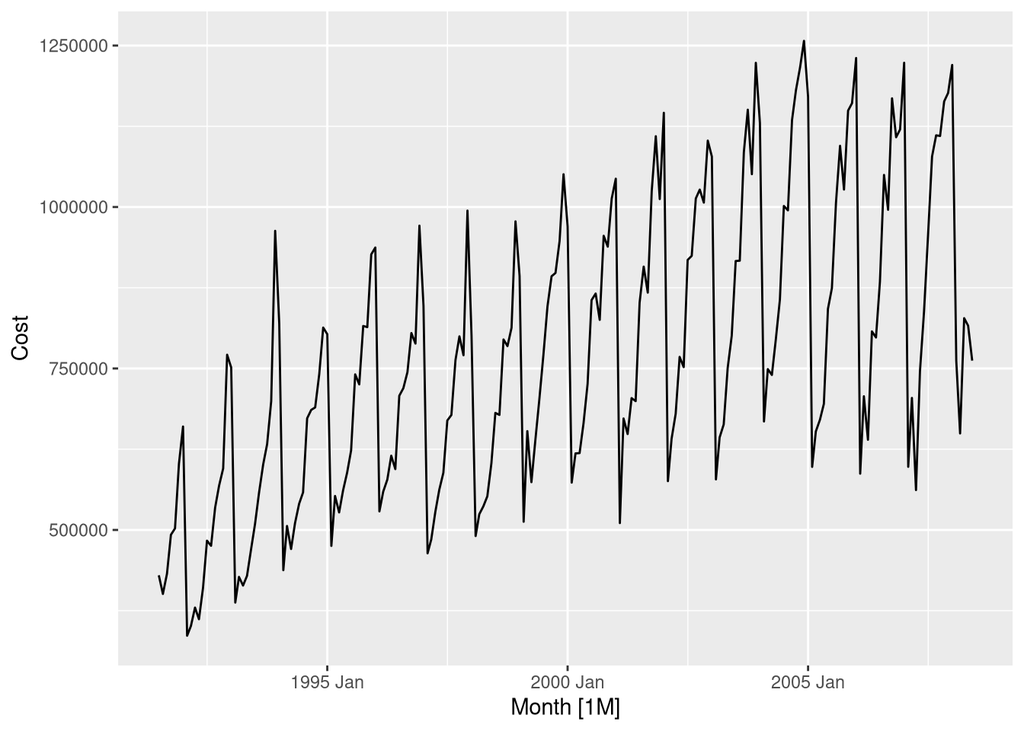

```r
h02 <- PBS |>
  filter(ATC2 == "H02") |>
  summarise(Cost = sum(Cost))

h02 |> autoplot(Cost)
```

### Calculator comparison

For the fixed `ETS(A,A,A)` model in Exercise 3, take `log_lik` from `glance()`, rounded to two decimals, and calculate AIC using $k=17$. For a second fixed candidate `ETS(M,Ad,M)` on the same data, use $k=18$. Compare both AIC values and check them against `glance()`. How much improvement in log-likelihood is needed to offset one extra parameter? Explain why the lower AIC need not win at your chosen forecast horizon.

A tibble prints a `log_lik` this large as a whole number, `-2776.`, which is not precise enough here. To read it to two decimals, pipe the selected `glance()` columns into `knitr::kable(digits = 2)`, as in the continuing example.

The supplied counts include smoothing parameters, free initial states and the innovation variance, counted as in the continuing example: with monthly data, eleven of the twelve initial seasonal states are free. Focus on the fit-versus-complexity tradeoff.

# Appendix: supporting explanations

Supporting reading for study after class. None of it is needed for the homework, the group assignments or the final.

## A short likelihood guide

In likelihood fitting, we keep the observations fixed and ask which model settings make them more plausible.

1. **Prediction and uncertainty belong together.** A forecast of 100 with a standard deviation of 2 describes a different distribution from a forecast of 100 with a standard deviation of 20.
2. **Density is not a probability at a point.** For continuous data, likelihood uses the heights of probability density curves at the observations. These heights need not be below one.
3. **A time series uses conditional densities.** At each date, predict using earlier information; evaluate that observation under its conditional distribution. Multiply those densities to obtain the likelihood, or add their logarithms to obtain the log-likelihood.
4. **Fit and complexity are separate questions.** Fitting chooses a model’s parameters. Model selection also asks whether extra flexibility earns its place.
5. **Forecast evaluation asks a different question.** AICc, defined in Section 5, is a fit score with a penalty for extra parameters. Like the SSE in Session 16 on fitting SES, it is computed on the training data, whereas rolling-origin evaluation, as in Session 14 on cross-validation, measures actual forecast errors at specified horizons.

Check your understanding: What stays fixed during estimation? Why is a very wide distribution not automatically a good fit? What is the difference between estimating alpha and selecting the trend type? Which errors matter for a twelve-month inventory decision? Why must model selection be repeated inside each training fold when evaluating an automatic procedure?

**TipAnswers: open after trying the questions**

- **What stays fixed during estimation?** The observations. Fitting varies the parameters and initial states and asks which values make those fixed data most plausible.
- **Why is a very wide distribution not automatically a good fit?** Widening the curve lowers its height near the prediction. In the Section 4 example, making the curve three times wider lowers its height at the observed value from 0.59 to 0.23. An observation far from its prediction can score higher under a wider curve. The total across all quarters determines the fitted spread.
- **Estimating alpha or selecting the trend type?** Estimating alpha is fitting: the form is fixed, and the likelihood chooses the value. Selecting the trend type compares different forms, each fitted first, so it needs a criterion that charges for the extra parameters, such as AICc.
- **Which errors matter for a twelve-month inventory decision?** Forecast errors at horizons up to twelve months, on data the model did not use for fitting. One-step training residuals do not measure them.
- **Why repeat selection inside each training fold?** Automatic selection is part of the procedure being evaluated. Choosing the form once on the full series would let earlier folds use information from their future.

## One update by hand, in both error forms

Take made-up numbers. Two models with no trend and no season, $ETS(A,N,N)$ and $ETS(M,N,N)$, both have the level $\ell_{t-1}=100$ and $\alpha=0.3$. The observation is $y_t=106$. For each model: predict $y_t$, compute the error, update the level and predict $y_{t+1}$. Then say what `.resid` and `.innov` would show for this quarter. Commit to your numbers before opening.

**TipWorked example: open after trying it**

| Step | $ETS(A,N,N)$ | $ETS(M,N,N)$ |
| --- | --- | --- |
| Predict $y_t$ | $\textcolor{#1F3A4D}{\hat y_{t\mid t-1}}=\textcolor{#1F3A4D}{\ell_{t-1}}=\textcolor{#1F3A4D}{100}$ | $\textcolor{#1F3A4D}{\hat y_{t\mid t-1}}=\textcolor{#1F3A4D}{\ell_{t-1}}=\textcolor{#1F3A4D}{100}$ |
| Error | $e_t=106-\textcolor{#1F3A4D}{100}=6$ | $\varepsilon_t=(106-\textcolor{#1F3A4D}{100})/\textcolor{#1F3A4D}{100}=0.06$ |
| Update the level | $\textcolor{#B5471E}{\ell_t}=\textcolor{#1F3A4D}{100}+0.3\times6=\textcolor{#B5471E}{101.8}$ | $\textcolor{#B5471E}{\ell_t}=\textcolor{#1F3A4D}{100}(1+0.3\times0.06)=\textcolor{#B5471E}{101.8}$ |
| Predict $y_{t+1}$ | $\textcolor{#B5471E}{\hat y_{t+1\mid t}}=\textcolor{#B5471E}{101.8}$ | $\textcolor{#B5471E}{\hat y_{t+1\mid t}}=\textcolor{#B5471E}{101.8}$ |
| `.resid` and `.innov` | 6 and 6 | 6 and 0.06 |

Slate marks what was known before the observation, the observation 106 is in black, and orange marks the updated level and its prediction, as in Sessions 17 and 18.

With the same $\alpha$ and the same level, the two models update to the same level and make the same next prediction. They differ in what they expect of the next surprise. Additive errors expect the same spread in units at any level; multiplicative errors expect the same spread as a proportion, so their spread in units grows with the level. That is the pattern of interval widths in section 3, and it is why the two models score the same data differently when they are fitted.

## A slice through the likelihood search

Section 4 describes the search `ETS()` runs for $ETS(M,N,A)$. To see the score’s shape, take a **slice** through the search: hold $\gamma$, the initial level and the initial seasonal states at their fitted values, vary $\alpha$ alone, and for each candidate run the predict-observe-update loop through the 80 quarters, as in Session 16. For $ETS(M,N,A)$ the updates are those of additive seasonal smoothing without a slope, written in error-correction form:

```r
# The selected ETS(M,N,A), under its own name in case fit was reused.
fit_auto <- fit_open |> select(auto)
est <- fit_auto |> tidy() |> select(term, estimate) |> deframe()

loglik_mna <- function(alpha, y = aus_holidays$Trips) {
  level  <- est[["l[0]"]]
  season <- est[c("s[-3]", "s[-2]", "s[-1]", "s[0]")]  # Q1 to Q4 before 1998 Q1
  pred <- err <- numeric(length(y))
  for (t in seq_along(y)) {
    pred[t] <- level + season[1]                    # predict y_t
    err[t]  <- (y[t] - pred[t]) / pred[t]           # relative error
    level   <- level + alpha * (y[t] - pred[t])     # update the level
    season  <- c(season[-1], season[1] + est[["gamma"]] * (y[t] - pred[t]))  # update the season
  }
  -0.5 * (length(y) * log(sum(err^2)) + 2 * sum(log(pred)))  # fable's log-likelihood
}

c(by_hand = loglik_mna(est[["alpha"]]), glance = glance(fit_auto)$log_lik)
```

```
  by_hand    glance
-106.1145 -106.1145
```

The function reproduces the log-likelihood `glance()` reports. The last line is `fable`’s formula for multiplicative errors: small relative errors raise the score, and the second term converts them back to trips. It leaves out constants that are the same for every candidate; the next section shows where it comes from. Now vary $\alpha$:

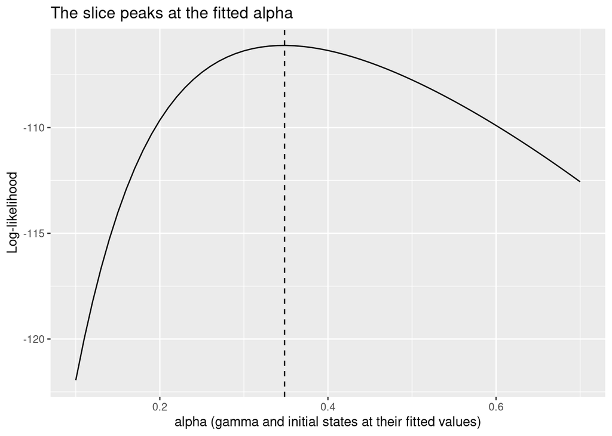

```r
slice <- tibble(alpha = seq(0.1, 0.7, by = 0.01)) |>
  mutate(log_lik = sapply(alpha, loglik_mna))

slice |>
  ggplot(aes(x = alpha, y = log_lik)) +
  geom_line() +
  geom_vline(xintercept = est[["alpha"]], linetype = "dashed") +
  labs(title = "The slice peaks at the fitted alpha",
       x = "alpha (gamma and initial states at their fitted values)",
       y = "Log-likelihood")
```

The slice peaks at the fitted $\alpha\approx0.35$. A small $\alpha$ lets the level lag the rise since 2015; a large one chases each quarter’s surprise. `ETS()` searched over six values at once; the slice shows one direction through that search near its end point. Refitting at each $\alpha$ instead would also re-choose $\gamma$ and the initial states, and the optimizer can stop at slightly different places, so that curve is jagged near the top.

## Where the likelihood score comes from

For $ETS(M,N,A)$ the observation equation is $y_t=\hat y_{t|t-1}(1+\varepsilon_t)$ with $\varepsilon_t\sim N(0,\sigma^2)$. Given the past, $y_t$ is normal with mean $\hat y_{t|t-1}$ and standard deviation $\hat y_{t|t-1}\sigma$, so its density at the observation is the density of $\varepsilon_t$ divided by $\hat y_{t|t-1}$. Adding the logarithms over $T$ quarters:

$$\log L=-\frac{T}{2}\log(2\pi\sigma^2)-\frac{1}{2\sigma^2}\sum_t\varepsilon_t^2-\sum_t\log\hat y_{t|t-1}.$$

For fixed predictions, the best $\sigma^2$ is $\sum_t\varepsilon_t^2/T$. Putting it back gives

$$\log L=-\frac{1}{2}\Big(T\log\sum_t\varepsilon_t^2+2\sum_t\log\hat y_{t|t-1}\Big)+\text{a constant that depends only on }T,$$

which is the last line of `loglik_mna()` in the slice, without the constant. `fable` reports the same quantity. The constant is identical for every model fitted to the same $T$ observations, so it cannot change a comparison.

For additive errors the term $\sum_t\log\hat y_{t|t-1}$ is absent and $\varepsilon_t$ is the error in units, so the log-likelihood is $-\tfrac{T}{2}\log(\text{SSE})$ plus a constant: the largest likelihood is the smallest SSE. `report()` prints a $\sigma^2$ that divides by $T$ minus the number of estimated parameters, so it is slightly larger than $\sum_t\varepsilon_t^2/T$.

## Model combinations that are excluded

The automatic search is smaller than the list of letters suggests. Three combinations of (Error, Trend, Season) can be numerically unstable, because their state equations divide by values that may be close to zero:

- $ETS(A, N, M)$
- $ETS(A, A, M)$
- $ETS(A, Ad, M)$

They are not considered when `ETS()` chooses a model. With trends N, A and Ad, errors A and M, and seasons N, A and M, that leaves 15 of the 18 combinations.

## The scoreboard behind the choice

Fitting the 15 eligible models ourselves shows what `ETS(Trips)` compared:

```r
fit_all <- aus_holidays |>
  model(
    ANN  = ETS(Trips ~ error("A") + trend("N")  + season("N")),
    AAN  = ETS(Trips ~ error("A") + trend("A")  + season("N")),
    AAdN = ETS(Trips ~ error("A") + trend("Ad") + season("N")),
    ANA  = ETS(Trips ~ error("A") + trend("N")  + season("A")),
    AAA  = ETS(Trips ~ error("A") + trend("A")  + season("A")),
    AAdA = ETS(Trips ~ error("A") + trend("Ad") + season("A")),
    MNN  = ETS(Trips ~ error("M") + trend("N")  + season("N")),
    MAN  = ETS(Trips ~ error("M") + trend("A")  + season("N")),
    MAdN = ETS(Trips ~ error("M") + trend("Ad") + season("N")),
    MNA  = ETS(Trips ~ error("M") + trend("N")  + season("A")),
    MAA  = ETS(Trips ~ error("M") + trend("A")  + season("A")),
    MAdA = ETS(Trips ~ error("M") + trend("Ad") + season("A")),
    MNM  = ETS(Trips ~ error("M") + trend("N")  + season("M")),
    MAM  = ETS(Trips ~ error("M") + trend("A")  + season("M")),
    MAdM = ETS(Trips ~ error("M") + trend("Ad") + season("M"))
  )

scores <- fit_all |>
  glance() |>
  select(.model, AICc) |>
  mutate(gap = AICc - min(AICc)) |>
  arrange(AICc)

scores |> knitr::kable(digits = 2)
```

| .model | AICc | gap |
| --- | --- | --- |
| MNA | 227.78 | 0.00 |
| MNM | 228.34 | 0.56 |
| MAA | 229.10 | 1.32 |
| MAM | 229.29 | 1.51 |
| ANA | 230.05 | 2.27 |
| AAA | 231.14 | 3.35 |
| MAdM | 231.33 | 3.55 |
| MAdA | 232.10 | 4.31 |
| AAdA | 232.37 | 4.59 |
| AAN | 364.74 | 136.95 |
| MAN | 365.77 | 137.99 |
| AAdN | 367.63 | 139.84 |
| ANN | 367.64 | 139.86 |
| MAdN | 368.42 | 140.64 |
| MNN | 368.59 | 140.80 |

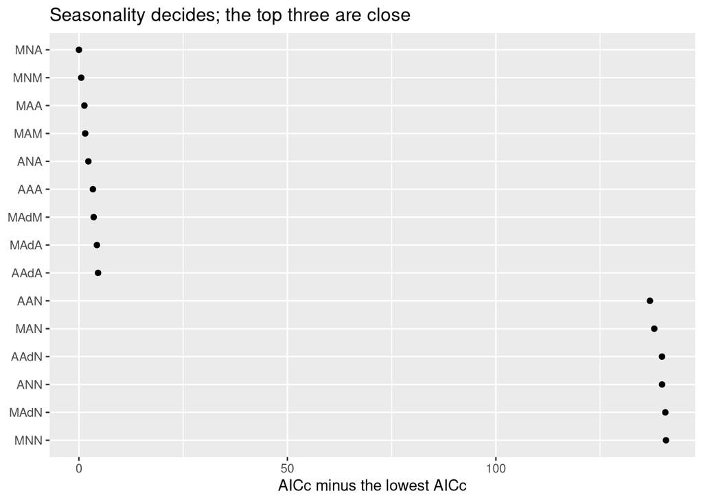

```r
scores |>
  ggplot(aes(x = gap, y = reorder(.model, -gap))) +
  geom_point() +
  labs(title = "Seasonality decides; the top three are close",
       x = "AICc minus the lowest AICc", y = NULL)
```

The scoreboard answers two questions at two scales. Every seasonal model beats every nonseasonal one by more than 130: seasonality is not in doubt. At the top, $ETS(M,N,M)$ is 0.56 behind and $ETS(M,A,A)$ 1.32 behind. A gap that small says the data hardly separate the three; the AICc still has to name one, and it names $ETS(M,N,A)$.

## Reference: BIC, the Bayesian Information Criterion

$$\text{BIC} = \text{AIC} + k[\log(T)-2]$$

For $T\geq8$, $\log T>2$, so BIC puts more weight on the parameter penalty than AIC. Use the same comparable candidate set when interpreting that difference.

## Information criteria and nested models

Information criteria combine the likelihood with a penalty for the number of parameters. For nested models fitted to the same data, adding parameters cannot reduce the best achievable likelihood: the larger model can reproduce the smaller one. Arbitrary ETS variants need not be nested. A complexity penalty discourages flexibility that improves training fit without enough evidence of predictive value; it does not guarantee good forecasts.

## Comparing across model families

Comparing AICc between ETS candidates fitted to the same observations and response scale is a safe workflow, not a theorem that information criteria can only compare one model family. Across families, likelihood conventions, constants and the observations included must also be compatible. Use rolling-origin evaluation on a common outcome scale when that comparability is uncertain, or when a particular horizon and loss matter (Session 14 on cross-validation).

## Zeros, transformations and multiplicative errors

Multiplicative errors are numerically unstable when the data contain zeros or negative values, so `ETS()` does not consider them for a series that is not strictly positive. For such a series, consider an additive-error specification and inspect its suitability. A transformation changes the modeling scale and requires its own justification; it does not automatically make a multiplicative model admissible. In particular, $\log(1+x)$ still maps zero to zero.

## Other ETS models: point forecasts and simulated intervals

- **Point forecasts.** `forecast()` returns distribution means in `.mean` for all ETS models. For multiplicative seasonal models, the traditional recursion obtained by setting future errors to zero need not equal that mean; use the returned distribution for decisions involving uncertainty.
- **Intervals.** The prediction intervals differ between models with additive and multiplicative components: with multiplicative errors they widen with the level of the series.
- **How they are computed.** For some ETS models there is no formula for the forecast variance. Then `forecast()` simulates many future paths and takes percentiles of them, parametric simulation with errors drawn from the assumed distribution. Residual bootstrapping instead samples fitted innovations; it is a different simulation choice.